# Activity Monitoring

George Lwevoola

May 13, 2016

This assignment makes use of data from a personal activity monitoring device. This device collects data at 5 minute intervals throughout the day. The data consists of two months of data from an anonymous individual collected during the months of October and November, 2012 and include the number of steps taken in 5 minute intervals each day.

Loading and preprocessing the data

```r
## Loading and preprocessing the data
## check whether the file has been downloaded previously
## if not proceed to download data file
if(!file.exists("activity.zip")){
  fileUrl <-"https://d396qusza40orc.cloudfront.net/repdata%2Fdata%2Factivity.zip"
  download.file(fileUrl,destfile="activity.zip")
  dateDownloaded <-date()
}

## Data file exists. Set up connection to read file
con1 <- unz(description="activity.zip", filename="activity.csv")
activity_dt<- read.csv(con1,sep=",",header=TRUE)
```

```r
## Summarize dataset to calculate the mean steps per day
## Ignoring missing data
library(dplyr)
mydt <- group_by(activity_dt,date)
mydtmeans <-summarize(mydt,meansteps=mean(steps))
print(mydtmeans)
```

```
## Source: local data frame [61 x 2]
##
##          date meansteps
##        (fctr)     (dbl)
## 1  2012-10-01        NA
## 2  2012-10-02   0.43750
## 3  2012-10-03  39.41667
## 4  2012-10-04  42.06944
## 5  2012-10-05  46.15972
## 6  2012-10-06  53.54167
## 7  2012-10-07  38.24653
## 8  2012-10-08        NA
## 9  2012-10-09  44.48264
## 10 2012-10-10  34.37500
## ..        ...       ...
```

Make a histogram of the total number of steps taken each day

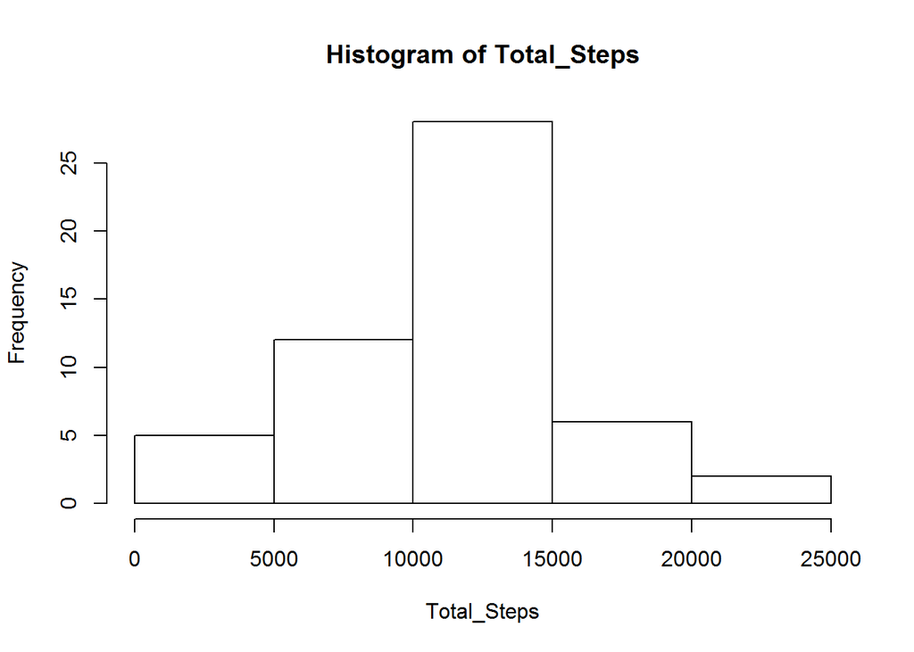

```r
## Calculate the total number of steps taken per day
## Make a histogram of the total number of steps taken each day
mydtsums <-summarize(mydt,totalsteps=sum(steps))
Total_Steps<-mydtsums$totalsteps
hist(Total_Steps)
```

```r
##Calculate and report the mean and median of the total number of steps taken per day
mydtmm <-summarize(mydt, mean=mean(steps),median=median(steps))
print(mydtmm)
```

```
## Source: local data frame [61 x 3]
##
##          date     mean median
##        (fctr)    (dbl)  (dbl)
## 1  2012-10-01       NA     NA
## 2  2012-10-02  0.43750      0
## 3  2012-10-03 39.41667      0
## 4  2012-10-04 42.06944      0
## 5  2012-10-05 46.15972      0
## 6  2012-10-06 53.54167      0
## 7  2012-10-07 38.24653      0
## 8  2012-10-08       NA     NA
## 9  2012-10-09 44.48264      0
## 10 2012-10-10 34.37500      0
## ..        ...      ...    ...
```

What is the average daily activity pattern? Make a time series plot (i.e. type = “l”) of the 5-minute interval (x-axis) and the average number of steps taken, averaged across all days (y-axis)

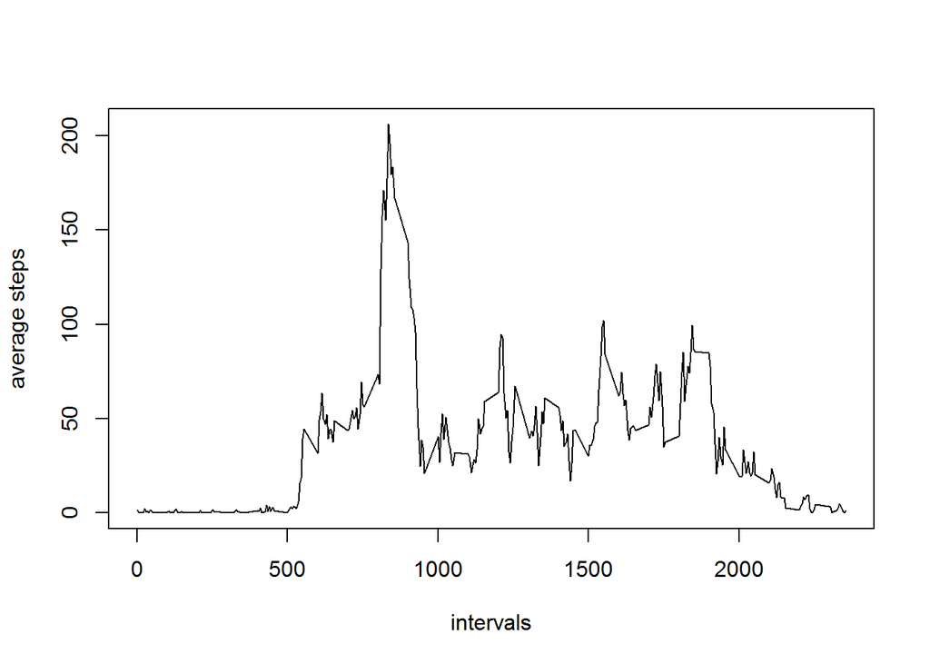

```r
mydt2 <- group_by(activity_dt,interval)
myplot<-summarize(na.omit(mydt2),steps=mean(as.numeric(steps)))
plot(myplot$interval,myplot$steps,type="l",xlab="intervals",ylab="average steps")
```

```r
subset(myplot, steps == max(steps))
```

```
## Source: local data frame [1 x 2]
##
##   interval    steps
##      (int)    (dbl)
## 1      835 206.1698
```

Imputing missing values Calculate and report the total number of missing values in the dataset (i.e. the total number of rows with NAs)

```r
print(missing <-sum(is.na(activity_dt$steps)))
```

```
## [1] 2304
```

The strategy devised for filling out the missing values is the replacement of NA’s with the mean

```r
mydata_NA<-arrange(activity_dt,interval)
library(plyr)
impute.mean <- function(x) replace(x, is.na(x), mean(x, na.rm = TRUE))
mydata_NA2 <- ddply(mydata_NA, ~ interval, transform, steps = impute.mean(steps))
mynew_dt <-mydata_NA2[order(mydata_NA2$date), ]
## detach plyr pacakage and reattach dplyr
detach(package:plyr)
library(dplyr)
```

New dataset that is equal to the original dataset but with the missing data filled in has been created.

Histogram of the total number of steps taken each day and the mean and median total number of steps taken per day

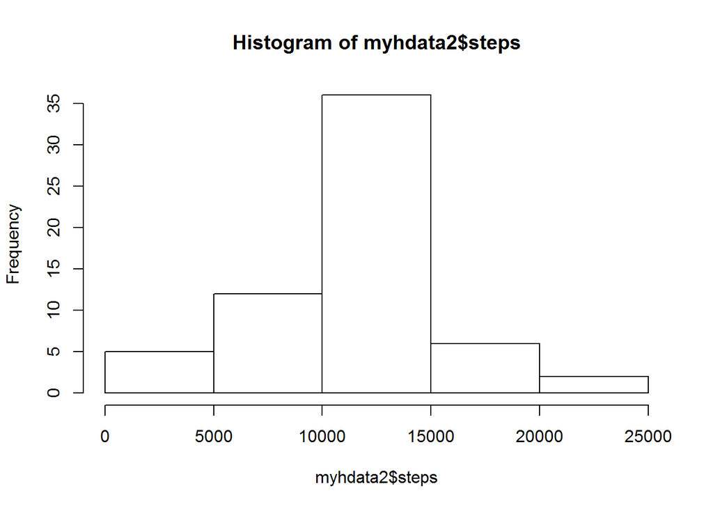

```r
## Make a histogram of the total number of steps taken each day and
myhdata <-group_by(mynew_dt,date)
myhdata2 <-summarize(myhdata,steps=sum(steps))
hist(myhdata2$steps)
```

The mean and median from the new data set

```r
print(myhdata3<-summarize(myhdata,mean=mean(steps),median=median(steps)))
```

```
## Source: local data frame [61 x 3]
##
##          date     mean   median
##        (fctr)    (dbl)    (dbl)
## 1  2012-10-01 37.38260 34.11321
## 2  2012-10-02  0.43750  0.00000
## 3  2012-10-03 39.41667  0.00000
## 4  2012-10-04 42.06944  0.00000
## 5  2012-10-05 46.15972  0.00000
## 6  2012-10-06 53.54167  0.00000
## 7  2012-10-07 38.24653  0.00000
## 8  2012-10-08 37.38260 34.11321
## 9  2012-10-09 44.48264  0.00000
## 10 2012-10-10 34.37500  0.00000
## ..        ...      ...      ...
```

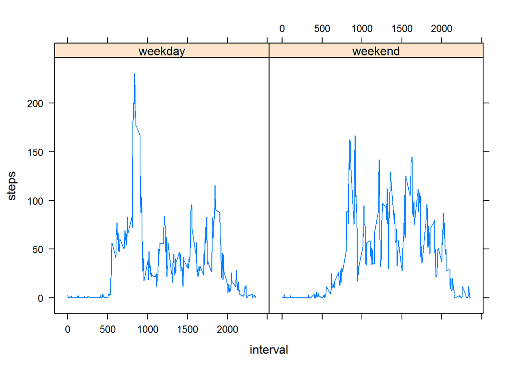

```r
## Create a new factor variable in the dataset with two levels -
## "weekday" and "weekend" indicating whether a given date is a weekday or weekend day.
mynew_dt$day <-weekdays(as.Date(mynew_dt$date))
mynew_dt$dday= as.factor(ifelse(as.character(mynew_dt$day) == "Saturday" | as.character(mynew_dt$day) == "Sunday", "weekend","weekday"))

## Make a panel plot containing a time series plot (i.e. type = "l") of the
## 5-minute interval (x-axis) and the average number of steps taken,
## averaged across all weekday days or weekend days (y-axis)
dt <- group_by(mynew_dt,interval,dday)
dt2<- summarize(dt,steps=mean(steps))

library(lattice)
xyplot(steps~interval|dday,type="l", data=dt2)
```